# The Manner of People in Exercise

Practical Machine Learning Course Project

Xinchun Tian

21 June, 2015

# Context

In this project, using the personal activity data collected by devices such as Jawbone Up, Nike FuelBand, and Fitbit, from accelerometers on the belt, forearm, arm, and dumbell of 6 participants, we are going to quantify how well people do a particular activity.

Load the packages that will be used in this analysis.

```r
suppressPackageStartupMessages(library(AppliedPredictiveModeling))
suppressPackageStartupMessages(library(caret))
suppressPackageStartupMessages(library(rattle))
suppressPackageStartupMessages(library(rpart.plot))
suppressPackageStartupMessages(library(randomForest))
```

# Getting and Cleaning the data (training + testing)

```r
if (!file.exists("pml-training.csv")) {
    url="https://d396qusza40orc.cloudfront.net/predmachlearn/pml-training.csv"
    download.file(url, destfile="./pml-training.csv", method="curl")
    dateDownloaded <- date()
}
if (!file.exists("pml-testing.csv")) {
    url="https://d396qusza40orc.cloudfront.net/predmachlearn/pml-testing.csv"
    download.file(url, destfile="./pml-testing.csv", method="curl")
    dateDownloaded <- date()
}
```

```r
# read in the data sets, both training and testing
training <- read.csv("pml-training.csv", na.strings=c("NA","","#DIV/0!"), sep=",")
testing  <- read.csv("pml-testing.csv",  na.strings=c("NA","","#DIV/0!"), sep=",")
# subset the data and keeps rows from 8 to the end
training <- training[,c(8:160)]
testing  <- testing[,c(8:160)]
# only keep the rows with less than 50% of missing values
col_to_keep = c()
for (i in 1:dim(training)[2]) {
  if ((sum(is.na(training[,i]))/nrow(training))<0.5) {
    col_to_keep <- append(col_to_keep, i)
  }
}
training <- training[,col_to_keep]
testing  <- testing[,col_to_keep]
dim(training)
```

```
## [1] 19622    53
```

```r
dim(testing)
```

```
## [1] 20 53
```

The idea is that if the fraction of missing values of a column is great than 50%, we will drop this column for downstream analysis. After the cleaning, there are 53 columns left including the outcome column “classe”. A further check has been done and found no missing values in the tidy data so there is no need to impute the training and testing data set.

```r
set.seed(123)
inTrain <- createDataPartition(y=training$classe, p=0.5, list=FALSE)
training0 <- training[inTrain,]
training1 <- training[-inTrain,]
```

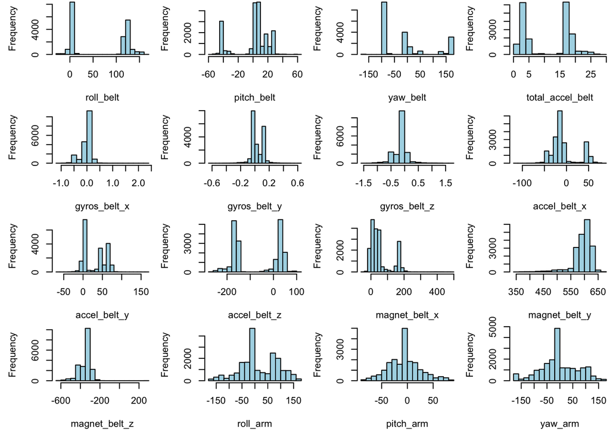

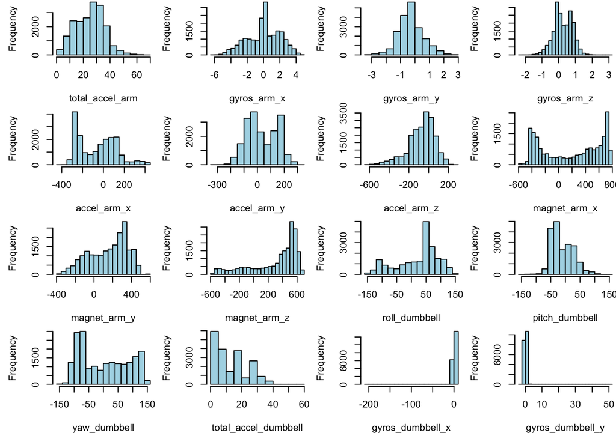

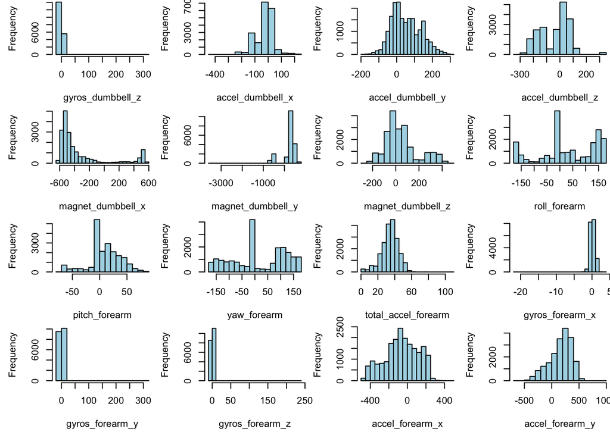

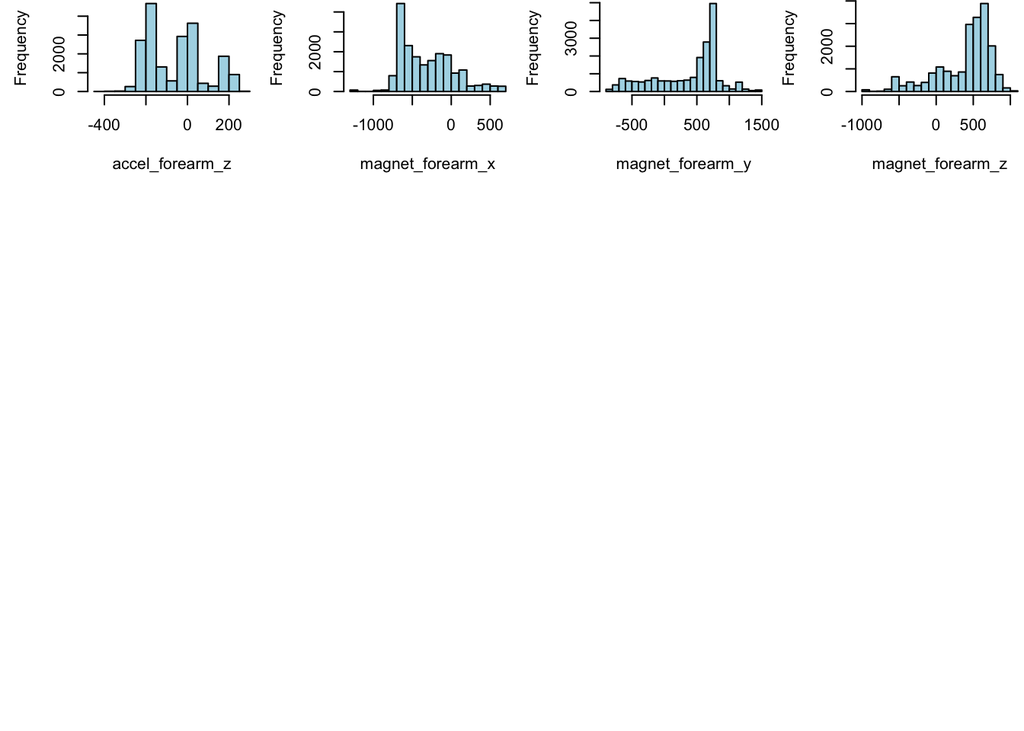

```r
par(mfrow=c(4,4))
par(mai=c(0.6,0.6,0,0))
tnames <- names(training)
for (i in 1:52) {
  hist(training[,i], xlab=tnames[i], breaks=20, col="lightblue", main="")
}
```

The plots show that many features are not normally distributed, so we have to apply proprocessing upon them.

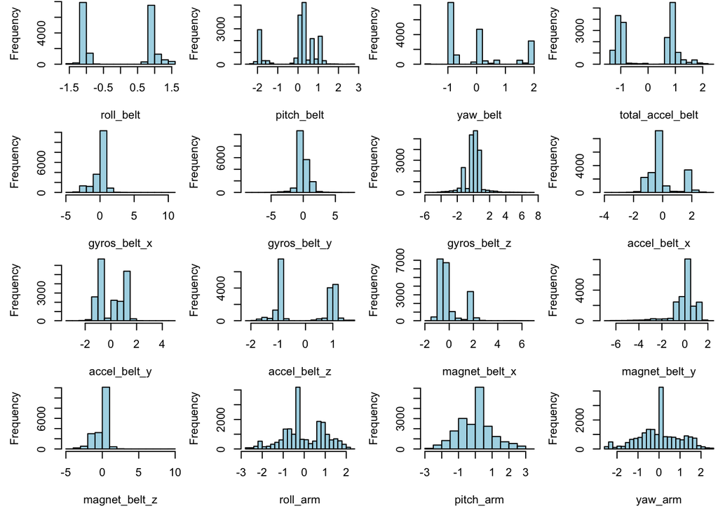

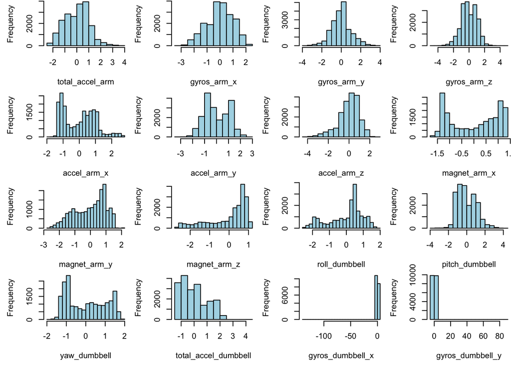

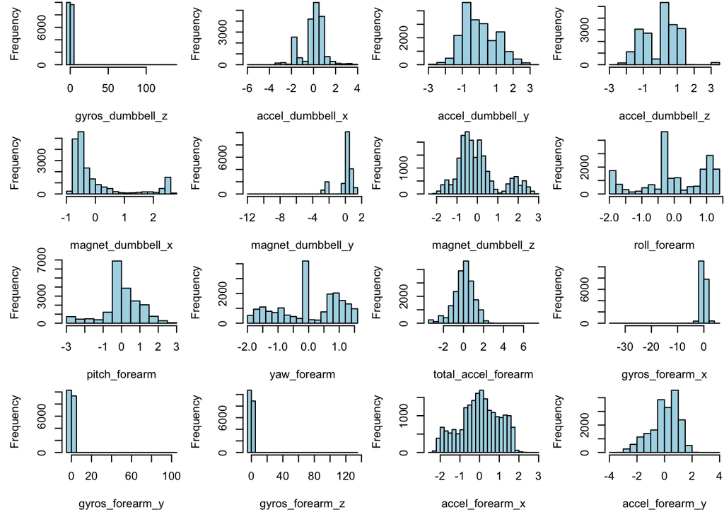

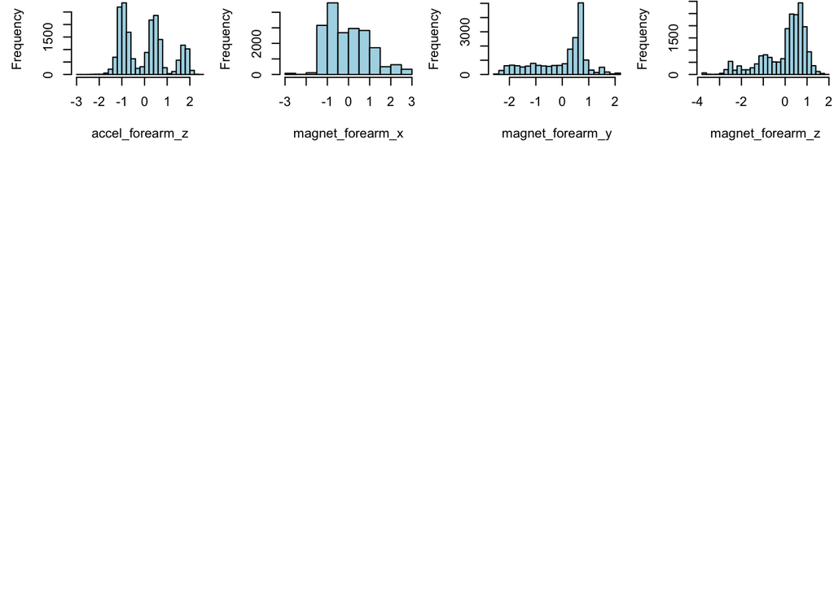

```r
par(mfrow=c(4,4))
par(mai=c(0.6,0.6,0,0))
preProTraining   <- preProcess(training[,-53], method=c("center","scale"))
predictTraining  <- predict(preProTraining, training[,-53])
for (i in 1:52) {
  hist(predictTraining[,i], xlab=tnames[i], breaks=20, col="lightblue", main="")
}
```

```r
# Train on training set 1 of 4 with both preprocessing and cross validation.
set.seed(666)
modFit <- train(training0$classe ~ .,  preProcess=c("center", "scale"), trControl=trainControl(method = "cv", number = 4), data = training0, method="rpart")

predictions <- predict(modFit, newdata=training1)
print(confusionMatrix(predictions, training1$classe), digits=4)
```

```
## Confusion Matrix and Statistics
##
##           Reference
## Prediction    A    B    C    D    E
##          A 2221  867  337  640  162
##          B  264  559   79  208  456
##          C  295  472 1295  760  355
##          D    0    0    0    0    0
##          E   10    0    0    0  830
##
## Overall Statistics
##
##                Accuracy : 0.5
##                  95% CI : (0.4901, 0.5099)
##     No Information Rate : 0.2844
##     P-Value [Acc > NIR] : < 2.2e-16
##
##                   Kappa : 0.3543
##  Mcnemar's Test P-Value : NA
##
## Statistics by Class:
##
##                      Class: A Class: B Class: C Class: D Class: E
## Sensitivity            0.7961  0.29452   0.7569   0.0000  0.46034
## Specificity            0.7142  0.87272   0.7676   1.0000  0.99875
## Pos Pred Value         0.5254  0.35696   0.4076      NaN  0.98810
## Neg Pred Value         0.8981  0.83758   0.9373   0.8361  0.89153
## Prevalence             0.2844  0.19348   0.1744   0.1639  0.18379
## Detection Rate         0.2264  0.05698   0.1320   0.0000  0.08461
## Detection Prevalence   0.4309  0.15963   0.3239   0.0000  0.08563
## Balanced Accuracy      0.7552  0.58362   0.7622   0.5000  0.72955
```

```r
# Train on training set 1 of 4 with no extra features.
#set.seed(666)
#trainControl <- trainControl(method="cv", number = 5)
#modelFit     <- train(training$classe ~ ., data = training0, trControl=trainControl, preProcess="pca",  method="rpart")
#confusionMatrix(testing$classe, predict(modelFit, testing))
```